# **CHE-1148 ASSIGNMENT-4**

## **1. Data Quality**

### **DFT ERROR ESTIMATION**

**Importing relevant packages**

```python
import pandas as pd
import numpy as np
import matplotlib.pyplot as plt
import seaborn as sns
from sklearn.model_selection import train_test_split
import sklearn
from sklearn import linear_model
from sklearn.linear_model import Ridge
from sklearn.metrics import mean_squared_error
```

**Importing the data**

```python
df = pd.read_excel("/content/data.xlsx", index_col=None, header=None)
df
```

|  | 0 | 1 | 2 | 3 | 4 | 5 | 6 | 7 | 8 | 9 | ... | 704 | 705 | 706 | 707 | 708 | 709 | 710 | 711 | 712 | 713 |
| --- | --- | --- | --- | --- | --- | --- | --- | --- | --- | --- | --- | --- | --- | --- | --- | --- | --- | --- | --- | --- | --- |
| 0 | 0 | 10 | 0 | 0 | 13 | 0 | 0 | 0 | 0 | 0 | ... | 0 | 0 | 0 | 0 | 9 | 16 | 0 | 0 | 0 | 55.595625 |
| 1 | 2 | 2 | 0 | 3 | 0 | 0 | 0 | 1 | 1 | 0 | ... | 0 | 0 | 0 | 0 | 5 | 3 | 4 | 1 | 0 | 133.960972 |
| 2 | 0 | 8 | 0 | 0 | 10 | 0 | 0 | 0 | 0 | 0 | ... | 0 | 0 | 0 | 0 | 8 | 15 | 0 | 1 | 0 | 57.694308 |
| 3 | 6 | 19 | 0 | 14 | 22 | 0 | 8 | 6 | 8 | 0 | ... | 0 | 0 | 0 | 0 | 22 | 26 | 0 | 0 | 0 | 172.426580 |
| 4 | 0 | 1 | 0 | 0 | 0 | 0 | 0 | 0 | 0 | 0 | ... | 0 | 0 | 0 | 0 | 2 | 6 | 1 | 0 | 0 | 22.202958 |
| ... | ... | ... | ... | ... | ... | ... | ... | ... | ... | ... | ... | ... | ... | ... | ... | ... | ... | ... | ... | ... | ... |
| 1671 | 0 | 9 | 1 | 0 | 8 | 1 | 0 | 0 | 0 | 0 | ... | 0 | 0 | 0 | 0 | 10 | 19 | 0 | 1 | 0 | 74.395230 |
| 1672 | 0 | 4 | 0 | 0 | 6 | 0 | 0 | 0 | 0 | 0 | ... | 0 | 0 | 0 | 0 | 7 | 12 | 4 | 0 | 0 | 104.435443 |
| 1673 | 3 | 11 | 0 | 10 | 12 | 0 | 8 | 3 | 8 | 0 | ... | 0 | 0 | 0 | 0 | 13 | 18 | 0 | 0 | 0 | 100.891600 |
| 1674 | 1 | 5 | 0 | 2 | 3 | 0 | 2 | 0 | 1 | 0 | ... | 0 | 0 | 0 | 0 | 7 | 14 | 0 | 0 | 0 | 44.644840 |
| 1675 | 3 | 7 | 0 | 7 | 7 | 0 | 4 | 3 | 4 | 0 | ... | 0 | 0 | 0 | 0 | 10 | 14 | 1 | 0 | 0 | 95.760584 |

1676 rows × 714 columns

```python
#Extracting X(feature data) and y (target variable) from the main dataframe
X = df.drop([713], axis = 1)
y = df[713]
```

```python
X
```

|  | 0 | 1 | 2 | 3 | 4 | 5 | 6 | 7 | 8 | 9 | ... | 703 | 704 | 705 | 706 | 707 | 708 | 709 | 710 | 711 | 712 |
| --- | --- | --- | --- | --- | --- | --- | --- | --- | --- | --- | --- | --- | --- | --- | --- | --- | --- | --- | --- | --- | --- |
| 0 | 0 | 10 | 0 | 0 | 13 | 0 | 0 | 0 | 0 | 0 | ... | 0 | 0 | 0 | 0 | 0 | 9 | 16 | 0 | 0 | 0 |
| 1 | 2 | 2 | 0 | 3 | 0 | 0 | 0 | 1 | 1 | 0 | ... | 0 | 0 | 0 | 0 | 0 | 5 | 3 | 4 | 1 | 0 |
| 2 | 0 | 8 | 0 | 0 | 10 | 0 | 0 | 0 | 0 | 0 | ... | 0 | 0 | 0 | 0 | 0 | 8 | 15 | 0 | 1 | 0 |
| 3 | 6 | 19 | 0 | 14 | 22 | 0 | 8 | 6 | 8 | 0 | ... | 0 | 0 | 0 | 0 | 0 | 22 | 26 | 0 | 0 | 0 |
| 4 | 0 | 1 | 0 | 0 | 0 | 0 | 0 | 0 | 0 | 0 | ... | 0 | 0 | 0 | 0 | 0 | 2 | 6 | 1 | 0 | 0 |
| ... | ... | ... | ... | ... | ... | ... | ... | ... | ... | ... | ... | ... | ... | ... | ... | ... | ... | ... | ... | ... | ... |
| 1671 | 0 | 9 | 1 | 0 | 8 | 1 | 0 | 0 | 0 | 0 | ... | 0 | 0 | 0 | 0 | 0 | 10 | 19 | 0 | 1 | 0 |
| 1672 | 0 | 4 | 0 | 0 | 6 | 0 | 0 | 0 | 0 | 0 | ... | 0 | 0 | 0 | 0 | 0 | 7 | 12 | 4 | 0 | 0 |
| 1673 | 3 | 11 | 0 | 10 | 12 | 0 | 8 | 3 | 8 | 0 | ... | 0 | 0 | 0 | 0 | 0 | 13 | 18 | 0 | 0 | 0 |
| 1674 | 1 | 5 | 0 | 2 | 3 | 0 | 2 | 0 | 1 | 0 | ... | 0 | 0 | 0 | 0 | 0 | 7 | 14 | 0 | 0 | 0 |
| 1675 | 3 | 7 | 0 | 7 | 7 | 0 | 4 | 3 | 4 | 0 | ... | 0 | 0 | 0 | 0 | 0 | 10 | 14 | 1 | 0 | 0 |

1676 rows × 713 columns

The dataset has 1676 rows and 713 columns. As per the information given in the question, the missing values were imputed with zeros.Hence, by just looking at the data we can infer that the data is sparse since it has a lot of missing information. To study the sparsity, I plot a sparsity patter plot.

**Sparsity Pattern**

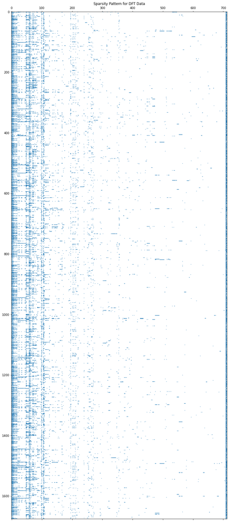

```python
#Sparsity Pattern
plt.figure(figsize=(20, 32))
plt.spy(X, precision=0, markersize=0.5)
plt.title("Sparsity Pattern for DFT Data")
plt.show()
```

**Percentage of non-zero elements in table X**

```python
print("The percentage of non-zero elements in X is: {:.2f} %".format(np.count_nonzero(X) / X.size * 100))
```

```
The percentage of non-zero elements in X is: 2.98 %
```

The above results show that the overall completeness of the data is 2.98%.

**Exploring the distribution of the output error we are predicting**

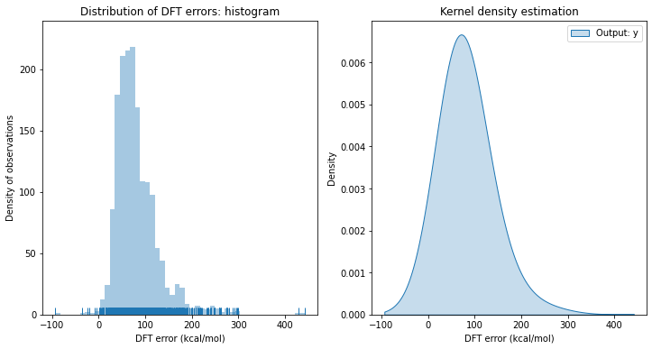

```python
f, axes = plt.subplots(1, 2, figsize=(12, 6))
# Left plot: Histogram
sns.distplot(y, kde=False, norm_hist=False, rug=True, label="Output: y", ax=axes[0])
axes[0].set_title('Distribution of DFT errors: histogram')
axes[0].set_xlabel('DFT error (kcal/mol)')
axes[0].set_ylabel('Count of observations')

# Right plot: Kernel Density Estimation
sns.kdeplot(y, shade=True, clip=(y.min(),y.max()), bw_method=1, label="Output: y", ax=axes[1])
axes[1].set_title('Kernel density estimation')
axes[1].set_xlabel('DFT error (kcal/mol)')
axes[0].set_ylabel('Density of observations')
plt.legend()
plt.show()
```

**Splitting data into training and test**

```python
X_train, X_test, y_train, y_test = train_test_split(X, y, test_size=0.3, random_state=1) #70-30 split for train-test
```

```python
print(X_train.shape, X_test.shape)
```

```
(1173, 713) (503, 713)
```

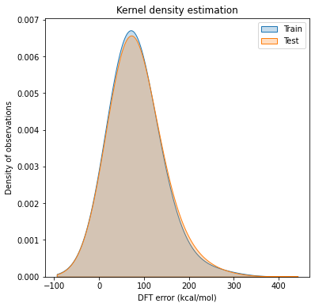

```python
f, axes = plt.subplots(1, 1, figsize=(6, 6))
# Train and Test: Kernel Density Estimation
sns.kdeplot(y_train, shade=True, clip=(y.min(),y.max()), bw_method=1, label="Train")
sns.kdeplot(y_test, shade=True, clip=(y.min(),y.max()), bw_method=1, label="Test")
axes.set_title('Kernel density estimation')
axes.set_xlabel('DFT error (kcal/mol)')
axes.set_ylabel('Density of observations')
plt.legend()
plt.show()
```

**Ridge Regression Model with L2 regularization**

```python
model_L2 = linear_model.Ridge(alpha=2.0) #ridge model

#training the model with train data
model_L2.fit(X_train, y_train)

#prediction on train data
y_pred_train = model_L2.predict(X_train)
train_error = mean_squared_error(y_pred_train, y_train, squared = False)
print("RMSE for train data is :", train_error)

#predicition test data
y_pred_test = model_L2.predict(X_test)
test_error = mean_squared_error(y_pred_test, y_test, squared = False)
print("RMSE for test data is :", test_error)
```

```
RMSE for train data is : 12.345806490560722
RMSE for test data is : 14.16014428198502
```

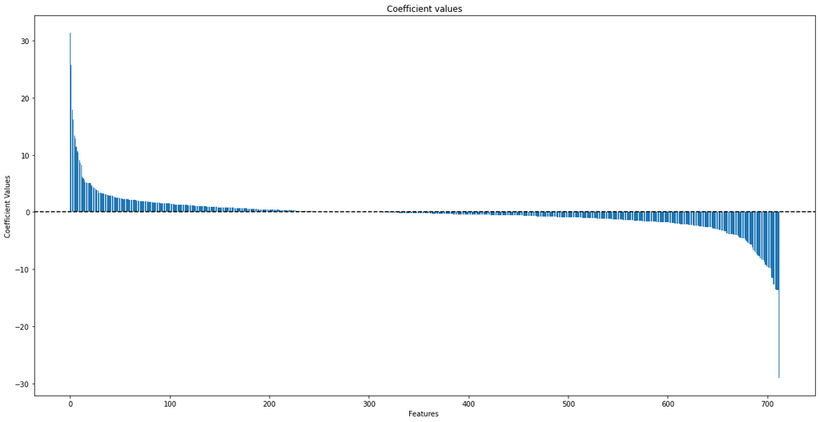

```python
coeff = model_L2.coef_
indices_annual_dt = np.argsort(coeff)[::-1]
names = [X_train.columns[i] for i in indices_annual_dt]

#plotting feature importance graph
plt.figure(figsize=(20,10))
plt.title("Coefficient values")
plt.bar(range(X_train.shape[1]), coeff[indices_annual_dt])
plt.axhline(y=0,color='k',linestyle='--')
plt.xlabel("Features ")
plt.ylabel("Coefficient Values")
plt.show()
```

**Feature Importance Vs Completeness**

```python
# Calculating completeness

completeness_list =[] #empty list to store completenes for each column

x_df = pd.DataFrame(X_train, columns=X_train.columns)
for i in range (len(x_df.columns)):
  completeness_list.append((np.count_nonzero(x_df.iloc[:,i])/len(x_df.iloc[:,i]))*100)
```

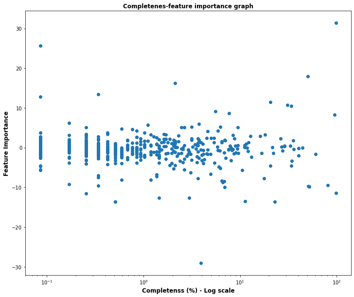

```python
#plotting feature importance vs completeness

plt.figure(figsize=(12,10))
plt.scatter(completeness_list, coeff)
plt.xscale('log')
plt.ylabel("Feature Importance", fontsize = 12, fontweight='bold')
plt.xlabel("Completenss (%) - Log scale", fontsize = 12, fontweight='bold')
plt.title("Completenes-feature importance graph", fontweight='bold')
```

Interpretation of the above feature importance vs completeness graph:

The plot essentially tells us the trade off between how much information each feature is capturing and how much each feature is contributing to the overall performance of the model.

This most deifinitelt indicates that there is an insufficient data to actually capture the importance of the features and hence we see this behaviour in the plot.

In order to imporve the model, I will gather more data to establish a good feature importance relationship and engineer features with higher importances too. I will also ensure that the features are complete to the maximum extent at the data collection stage. One way to do this is to make most columns of data manadatory to fill. This will improve the model significantly.